# prosperLoanData

Ramin Mohammadi

May 9, 2017

## Abstract

I explore a data set about Prospect loans p2p. My goals with the study are understanding how this practice works and find what seems to affect the borrower rate.

## Introduction

Dataset has 113937 records with 81 variables (including Date, characters, and numeric)

### Summary of data set

```
## 'data.frame':    113937 obs. of  81 variables:
##  $ ListingKey                         : chr  "1021339766868145413AB3B" "10273602499503308B223C1" "0EE9337825851032864889A" "0EF5356002482715299901A" ...
##  $ ListingNumber                      : int  193129 1209647 81716 658116 909464 1074836 750899 768193 1023355 1023355 ...
##  $ ListingCreationDate                : chr  "2007-08-26 19:09:29.263000000" "2014-02-27 08:28:07.900000000" "2007-01-05 15:00:47.090000000" "2012-10-22 11:02:35.010000000" ...
##  $ CreditGrade                        : chr  "C" NA "HR" NA ...
##  $ Term                               : int  36 36 36 36 36 60 36 36 36 36 ...
##  $ LoanStatus                         : chr  "Completed" "Current" "Completed" "Current" ...
##  $ ClosedDate                         : chr  "2009-08-14 00:00:00" NA "2009-12-17 00:00:00" NA ...
##  $ BorrowerAPR                        : num  0.165 0.12 0.283 0.125 0.246 ...
##  $ BorrowerRate                       : num  0.158 0.092 0.275 0.0974 0.2085 ...
##  $ LenderYield                        : num  0.138 0.082 0.24 0.0874 0.1985 ...
##  $ EstimatedEffectiveYield            : num  NA 0.0796 NA 0.0849 0.1832 ...
##  $ EstimatedLoss                      : num  NA 0.0249 NA 0.0249 0.0925 ...
##  $ EstimatedReturn                    : num  NA 0.0547 NA 0.06 0.0907 ...
##  $ ProsperRating..numeric.            : int  NA 6 NA 6 3 5 2 4 7 7 ...
```

[output cut: 67 more lines]

# **variables selection**

Following variable have been dropped as in order to make the analysis easier to undrestand

looking throug dataset and droping column which have more than 2000 records empty or NA

# Univariate ploting

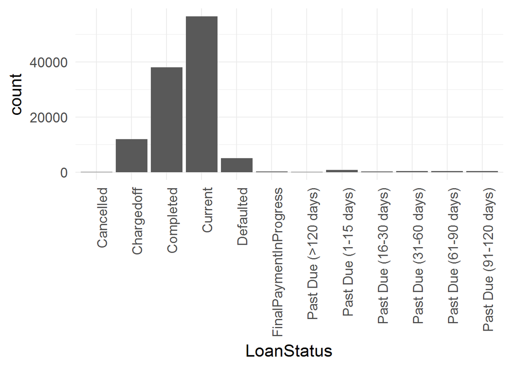

As we can see we are having mutiple ‘past due’ based on different day values , for simplicity and making our plot to be easier to undrestand i convert all values whihc start with “Past” to “Past Due”

Also we can see Cancelled status is only happening 5 times out of 113932 records, so i remove those records

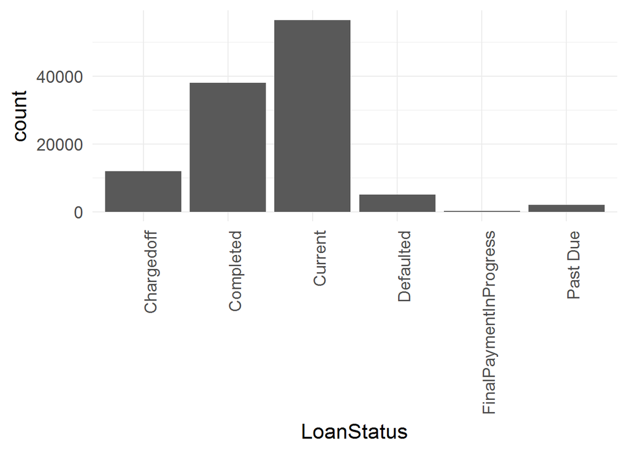

majority of loans in our datase are in current status then second majority is completed however we can see we have final payment in progress which are not much so i am removing the cases which are final payments

```
##
## Chargedoff  Completed    Current  Defaulted   Past Due
##      11992      38074      56576       5018       2067
```

We can see our plot is more undrestandable

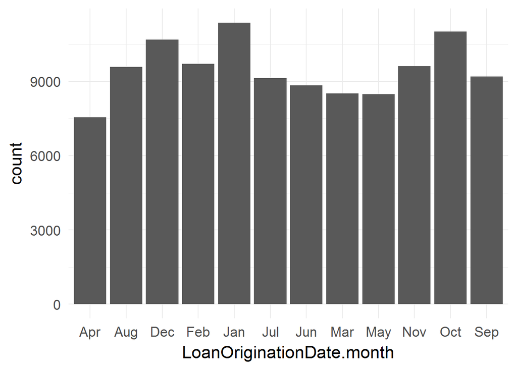

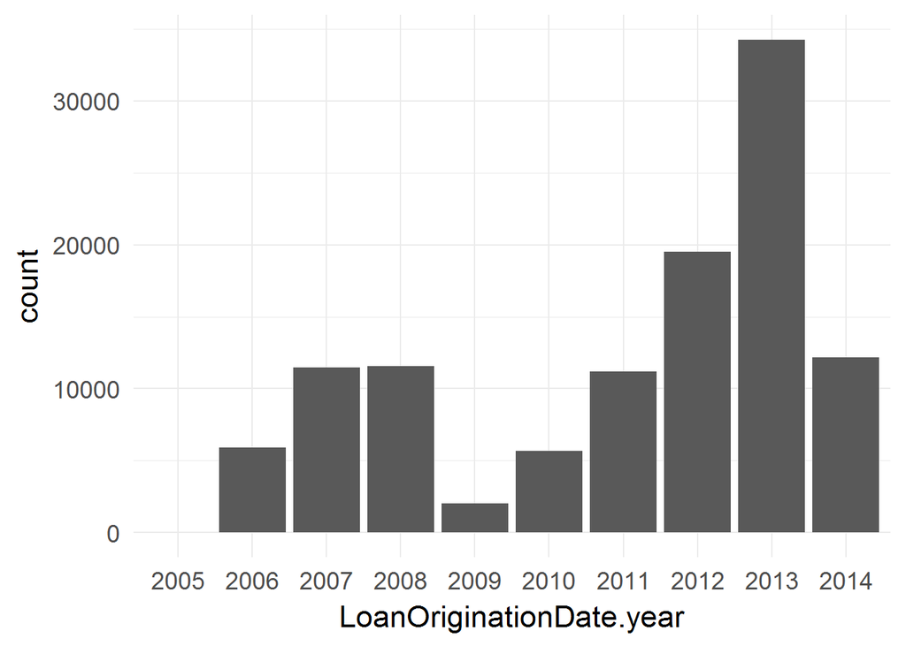

Most of the loans happend on 2013 and also highest amount of loan request are first month of the year and october , we can check for reason in multivariate analysis to see what is the reason behind

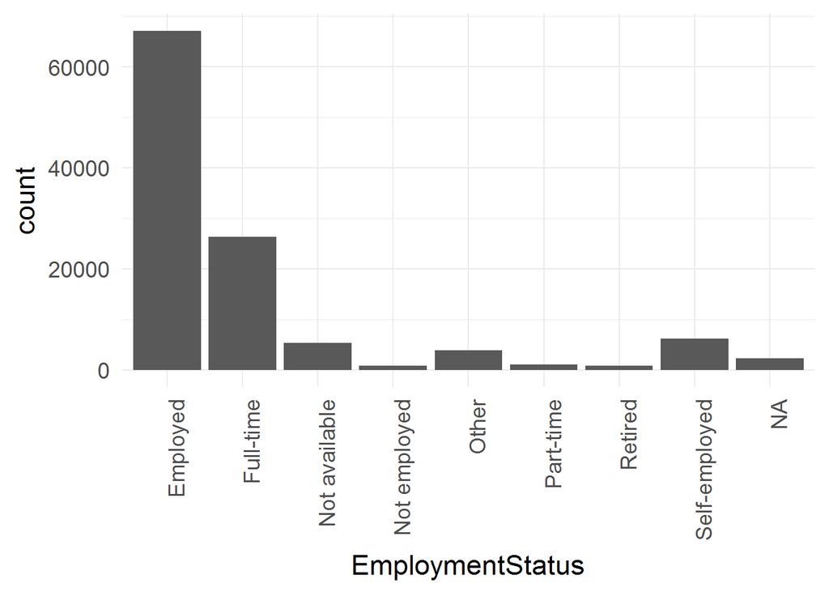

mixing “not available”, “other” and “NA” values for Employment Status and change them to “Not Available”, Also we can see we are having a value as Employed which can contain (Fulltime or PartTime) so for simplicity i mix them together

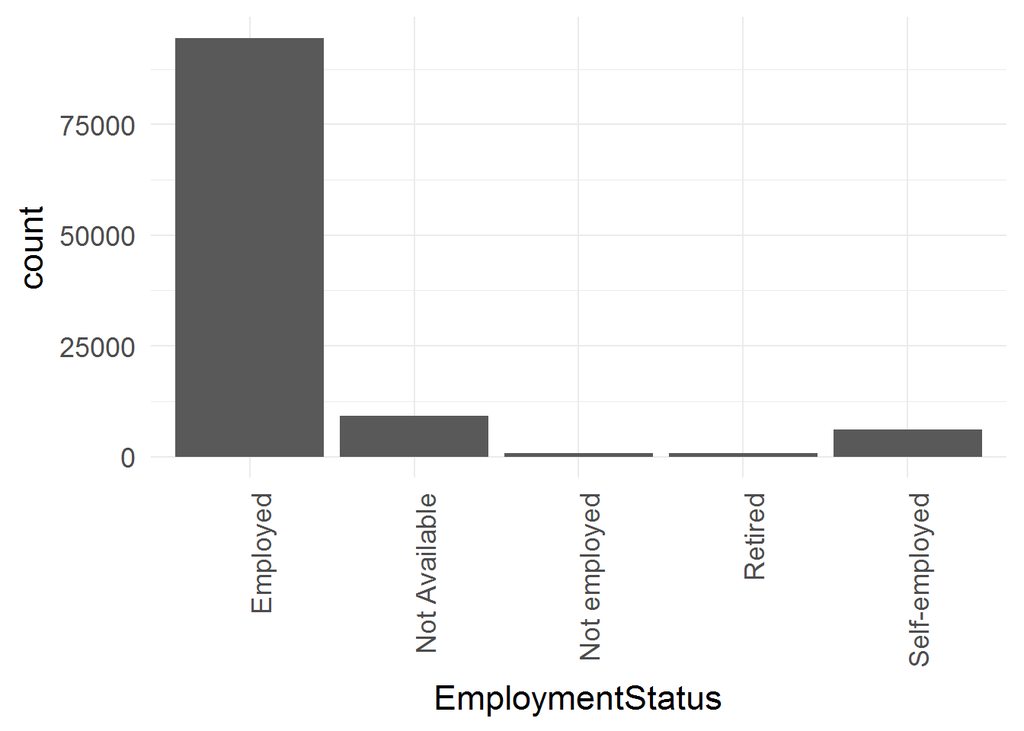

```
##
##      Employed  Not employed       Retired Self-employed
##         94577           835           795          6124
```

We can see we have more Employed than other values which is expecting, however Not available is not quite clear as for getting loan you need to provide that information

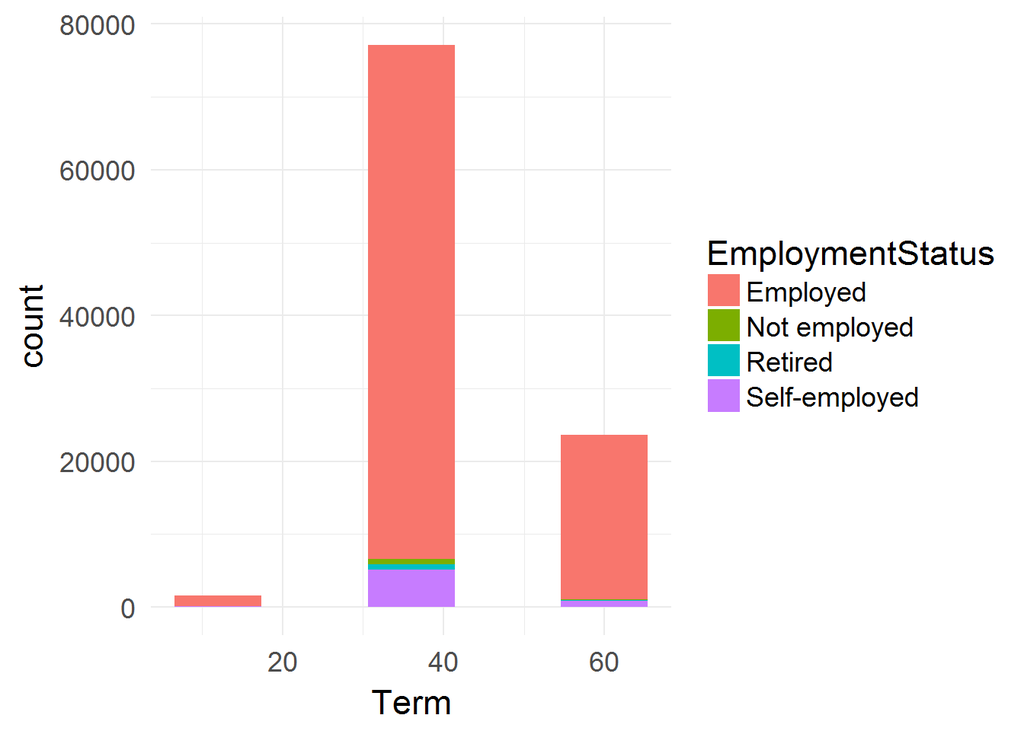

```
##
##    12    36    60
##  1555 77124 23652
```

We can see most of the Loans having 36 months terms which also expecting as having higher terms will require paying more intrest and having lower term means monthly payment should be more , also we can see retired class are having 36 months loans mostly

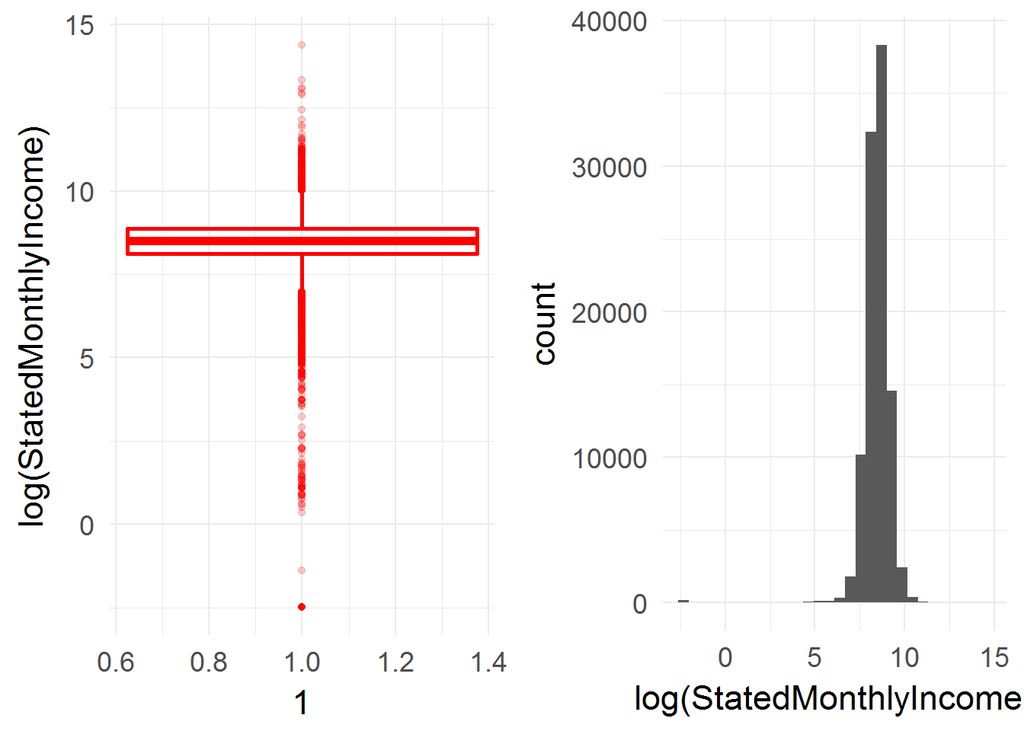

```
##    Min. 1st Qu.  Median    Mean 3rd Qu.    Max.
##       0    3333    4833    5747    7000 1750000
```

at this point there are 1393 case which have income of 0, my assumption is either there has been a mistake or input is wrong as bank will not provide you a loan with income of 0 , so for my work i get ride of records with income of 0 , ALSO i am intrested in monthly incomes less than equal to 10000 as more than 10000 is not likly to happen

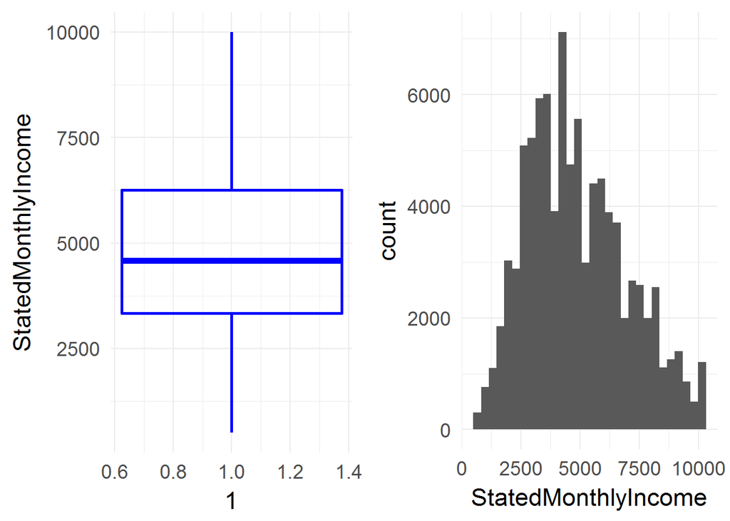

we can see median is 4538 and we have majority of data within first quartile and third quartile (3317,6250)

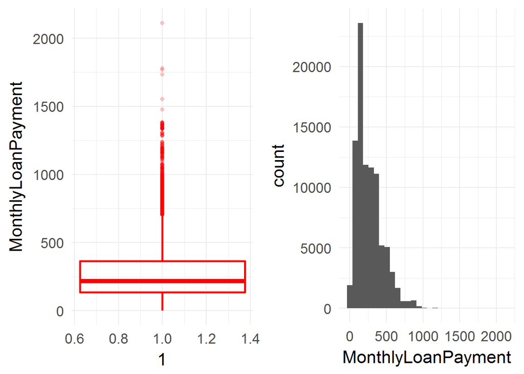

```
##    Min. 1st Qu.  Median    Mean 3rd Qu.    Max.
##     0.0   135.7   219.0   265.5   363.1  2112.0
```

looking at summary table we can see monthly loan payment of 0 which indicates of wrong data, as we can not have monthly payment of 0, i will remove records with value of 0 , also we only have 473 case with monthly payment of greater than 700$ , i removed those case as well as they are outlier to me.

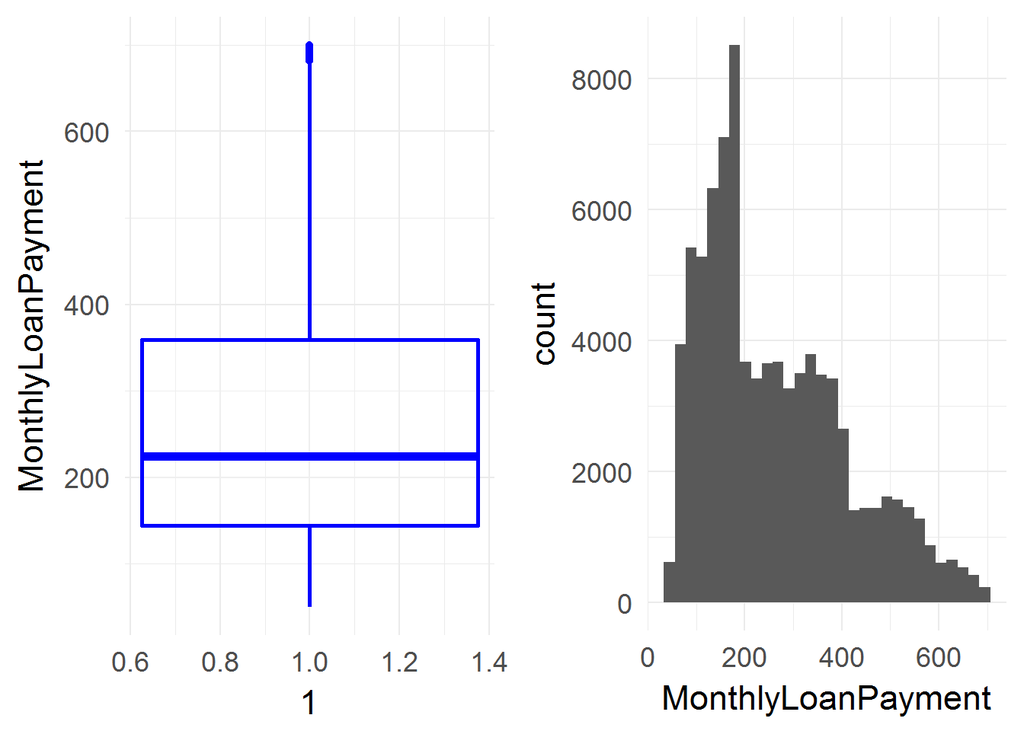

monthly loan payment has distribution which is right skewed

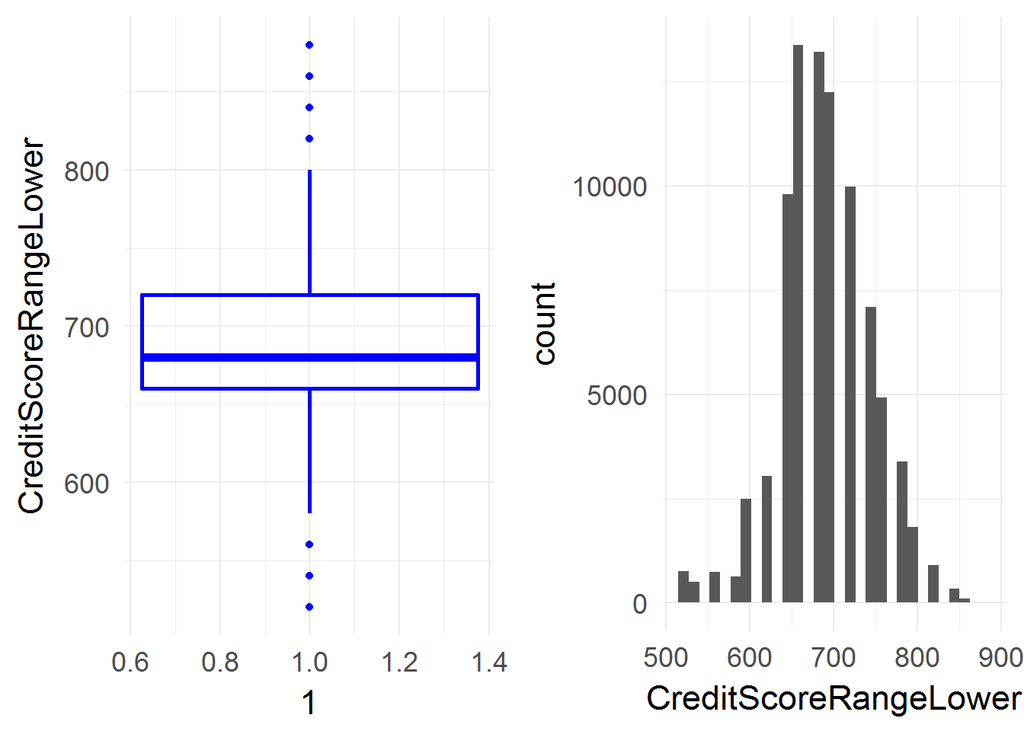

```
##    Min. 1st Qu.  Median    Mean 3rd Qu.    Max.
##   520.0   660.0   680.0   689.8   720.0   880.0
```

lower credite score range has ouliers based on box-plot , i consider to eliminate records with lower credite range less than 550 and higher than 800

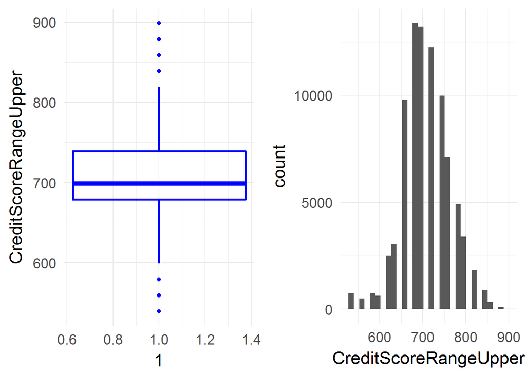

[output not shown]

i have consider same condition for Upper range credit, so i rmoved credite range less than 550 and higher than 800

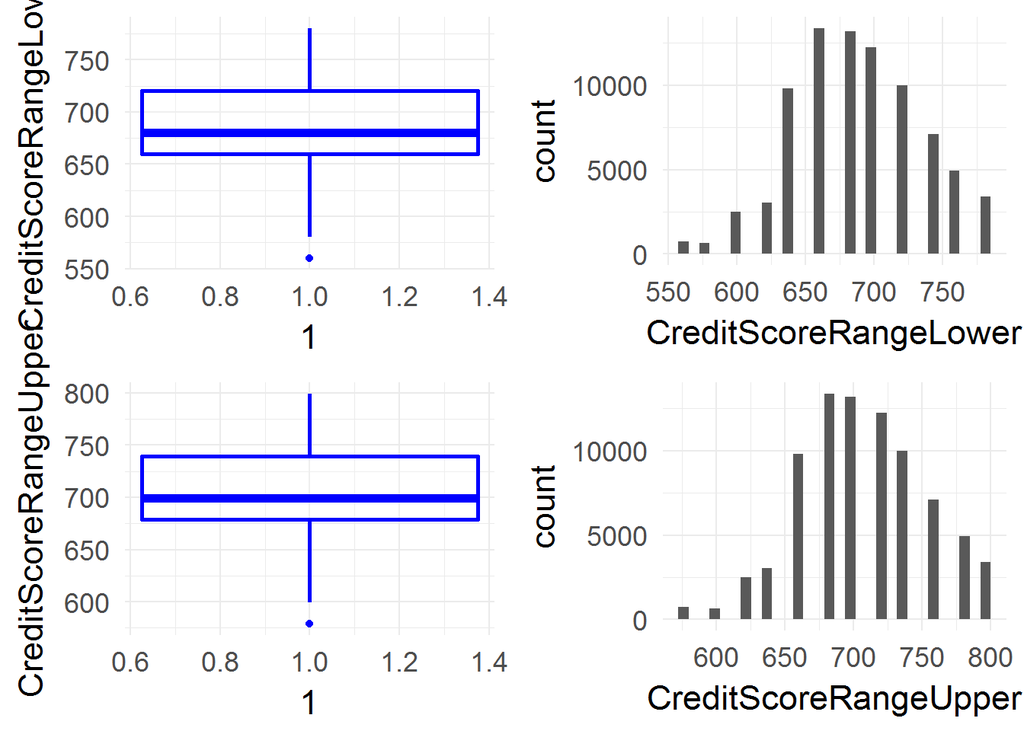

we can see both Upper and Lowe rcredit range having similar distribution however, they are having slightly different quartiles. later i am creating a new variable as average credit score and remove Upper and Lower scores.

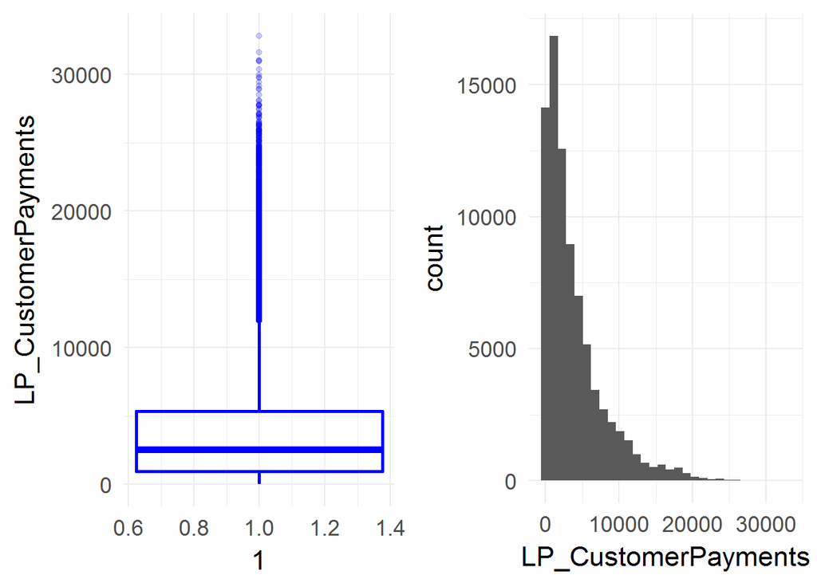

```
##     Min.  1st Qu.   Median     Mean  3rd Qu.     Max.
##    -2.35   913.50  2524.00  3868.00  5323.00 32800.00
```

we can see here that on minimum value we are having negative value which indicate of either wrong input or wrong value, i will remove all records with values less than 0 and higher than 12000.

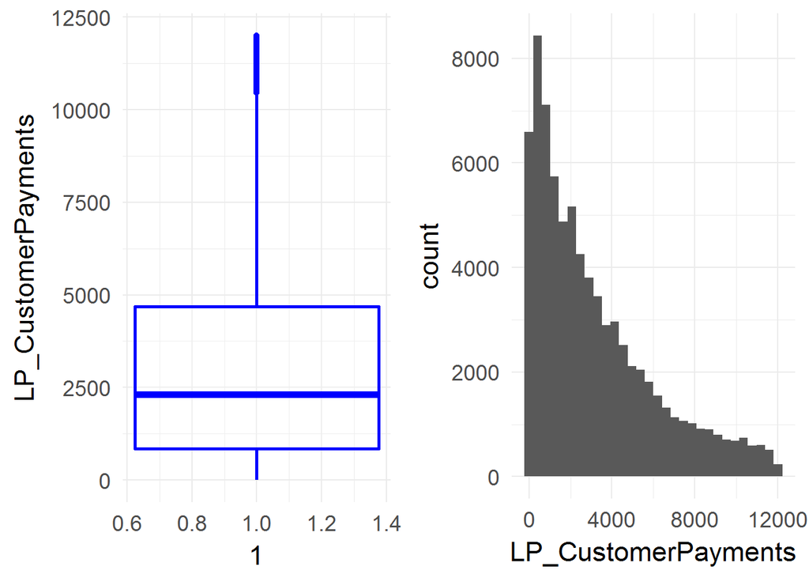

distribution is right skewed with median as 2338 , and we can see majority have payment less than 4702 which is 3rd quartil.

# Bivariate Analysis

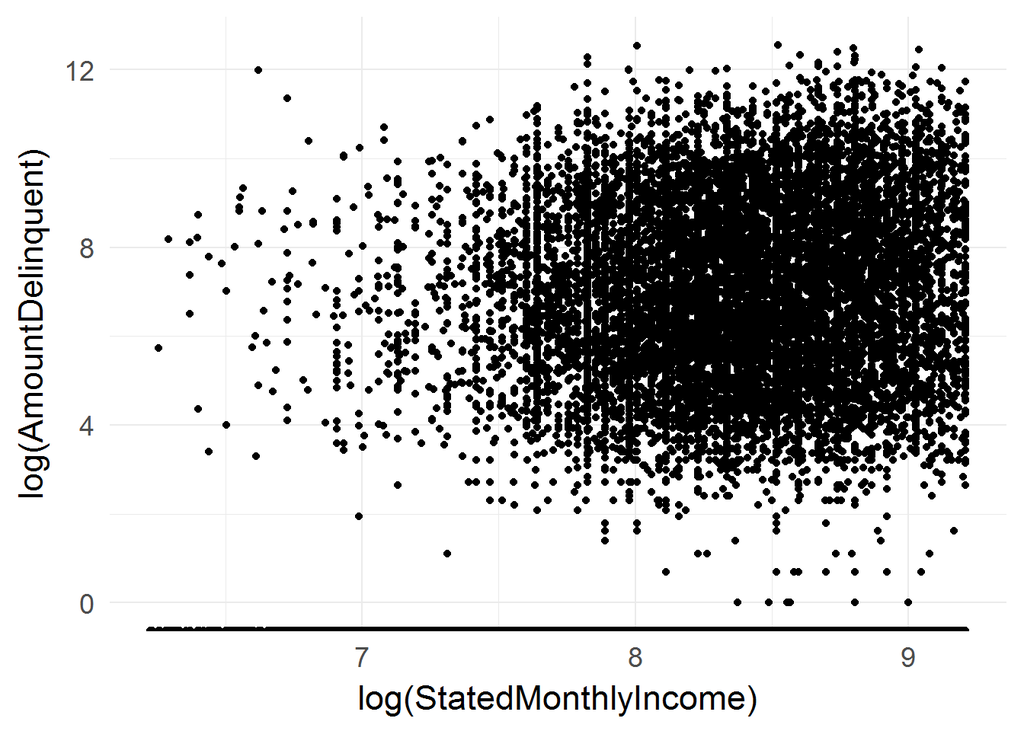

it seems that people with higher monthly incomes are more delinquent, i will add third variable to color the plot based on income Ranege

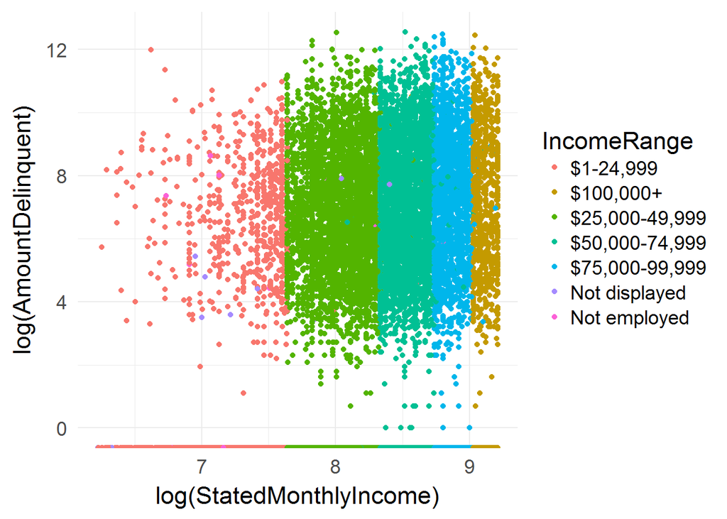

we can see chance of being delinquent incerases as income goes higher and when incomes reaches to 100K slightly decrase.

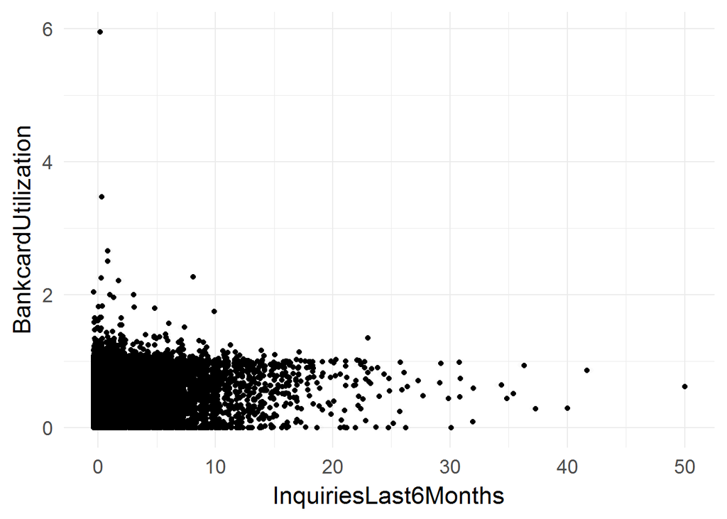

i have not seen much relation between bank card utilization and inquires within last 6 month, however it seems higher inquires tends to have abit less utilization, so i am looking in more details and create buckets for number of inquiries

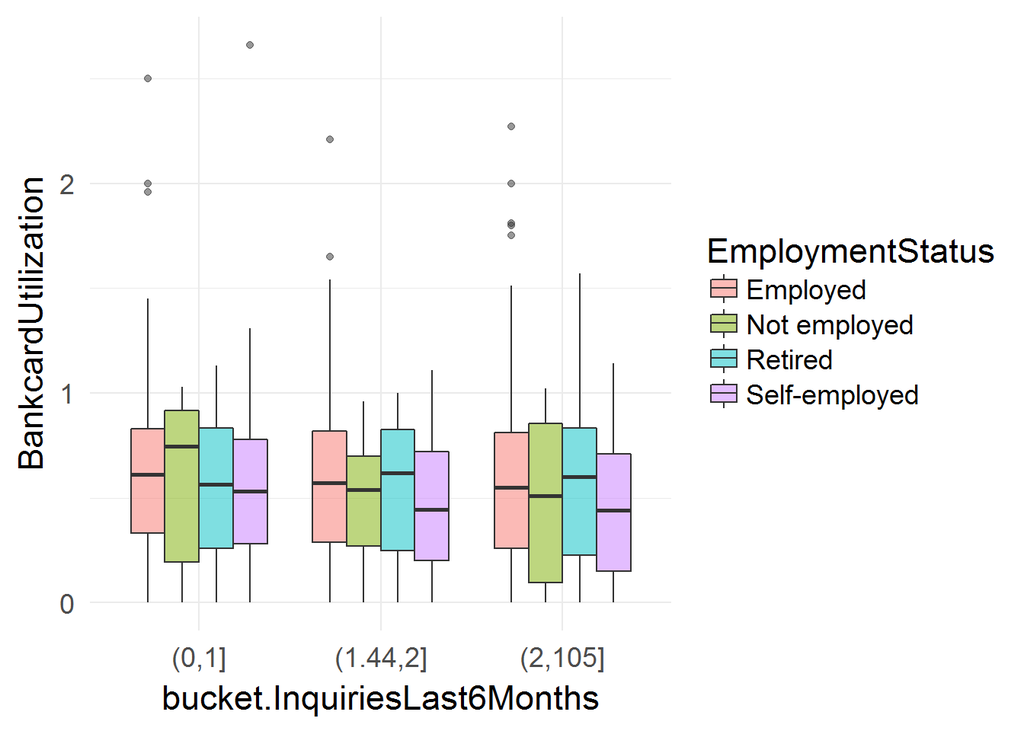

intresting fact i have found is self-employes tends to always having lower median than other people.

# Multivariate analysis

i have created a new variable for average of credit scores ( Lower and Upper) and removed upper and lower range variables

```
##    Min. 1st Qu.  Median    Mean 3rd Qu.    Max.
##   569.5   669.5   689.5   695.7   729.5   789.5
```

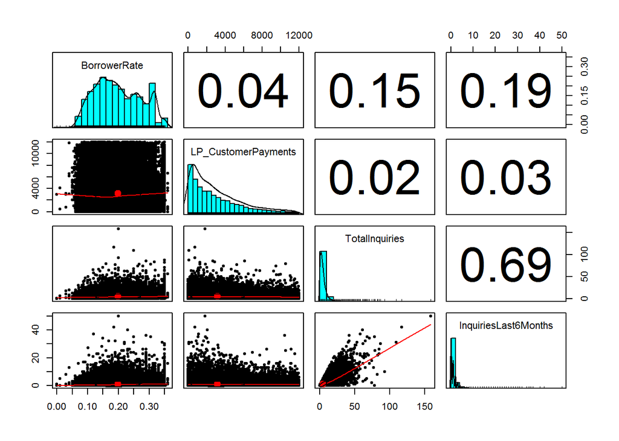

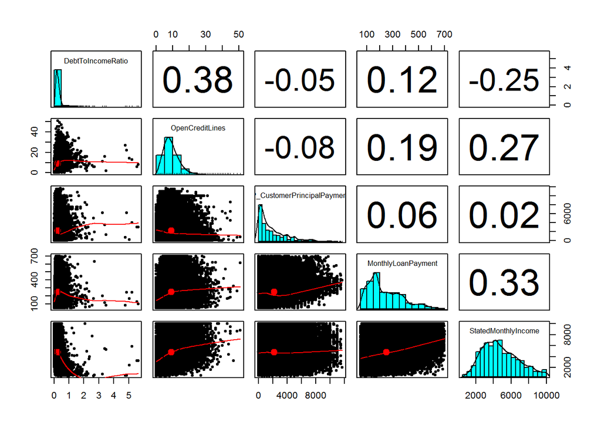

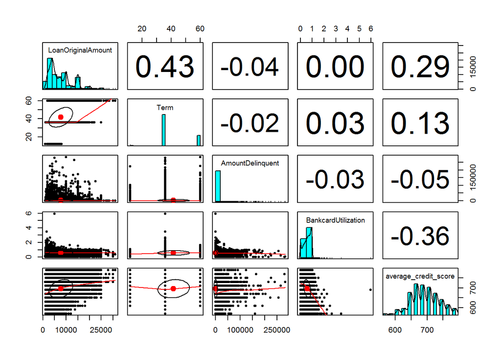

also for simplicity and due to having several columns it might be easier also to look at correlation values only

```
##                              BorrowerRate LP_CustomerPayments
## BorrowerRate                  1.000000000         0.026151565
## LP_CustomerPayments           0.026151565         1.000000000
## TotalInquiries                0.156490416         0.022570500
## InquiriesLast6Months          0.200695291         0.028414700
## DebtToIncomeRatio             0.148873661        -0.013999229
## OpenCreditLines              -0.070953477        -0.068313158
## LP_CustomerPrincipalPayments -0.083515302         0.951795513
## MonthlyLoanPayment           -0.246610229         0.139467865
## StatedMonthlyIncome          -0.143644517         0.032727448
## LoanOriginalAmount           -0.337905321         0.068347377
## Term                          0.004646364        -0.117841384
## AmountDelinquent              0.061881739        -0.001692444
## BankcardUtilization           0.219833111        -0.074049480
## average_credit_score         -0.460198628         0.087119691
##                              TotalInquiries InquiriesLast6Months
## BorrowerRate                    0.156490416           0.20069529
## LP_CustomerPayments             0.022570500           0.02841470
## TotalInquiries                  1.000000000           0.69705293
## InquiriesLast6Months            0.697052925           1.00000000
## DebtToIncomeRatio               0.009634313          -0.02746994
## OpenCreditLines                 0.120936535           0.03324081
## LP_CustomerPrincipalPayments    0.025935294           0.02830321
## MonthlyLoanPayment             -0.077040776          -0.10209987
## StatedMonthlyIncome             0.096477611           0.05001058
## LoanOriginalAmount             -0.109227254          -0.14140661
## Term                           -0.099237530          -0.11229828
## AmountDelinquent                0.026399073           0.02246410
## BankcardUtilization            -0.014369327          -0.06713653
## average_credit_score           -0.256119339          -0.20014655
##                              DebtToIncomeRatio OpenCreditLines
## BorrowerRate                       0.148873661     -0.07095348
## LP_CustomerPayments               -0.013999229     -0.06831316
## TotalInquiries                     0.009634313      0.12093654
## InquiriesLast6Months              -0.027469942      0.03324081
## DebtToIncomeRatio                  1.000000000      0.38339229
## OpenCreditLines                    0.383392292      1.00000000
## LP_CustomerPrincipalPayments      -0.049216514     -0.07520979
## MonthlyLoanPayment                 0.124454076      0.18976134
## StatedMonthlyIncome               -0.249879206      0.26717027
```

[output cut: 65 more lines]

```
##                              average_credit_score
## BorrowerRate                         -0.460198628
## LP_CustomerPayments                   0.087119691
## TotalInquiries                       -0.256119339
## InquiriesLast6Months                 -0.200146549
## DebtToIncomeRatio                     0.005415324
## OpenCreditLines                       0.123491430
## LP_CustomerPrincipalPayments          0.108915248
## MonthlyLoanPayment                    0.227931689
## StatedMonthlyIncome                   0.134075730
## LoanOriginalAmount                    0.295087684
## Term                                  0.140050067
## AmountDelinquent                     -0.050918863
## BankcardUtilization                  -0.359444538
## average_credit_score                  1.000000000
```

i am intrested in correlations higher than 0.3 as they seems good and as the correlation get closer to 1 it will be better, in this analysis i am looking at Borrower rate and find out variables which are correlated to it and can help, we can see Loan original amount, average credit score having highest correlation with borrower rate.

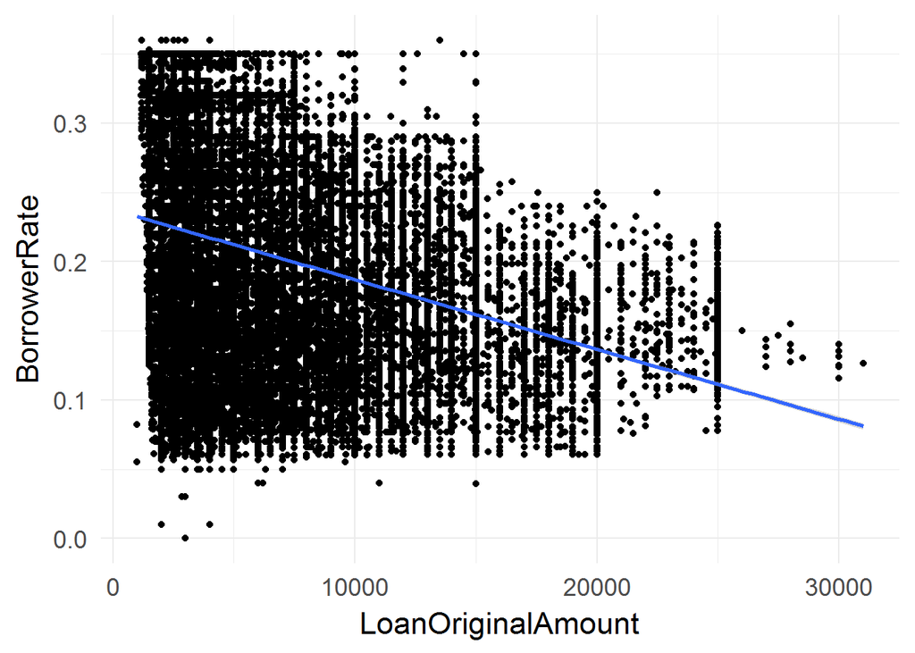

first look we can see ther seems to be a relation and having higher loan amount tends to getting lower rate, however i will go forward and create buckets for original amount and re create the plot

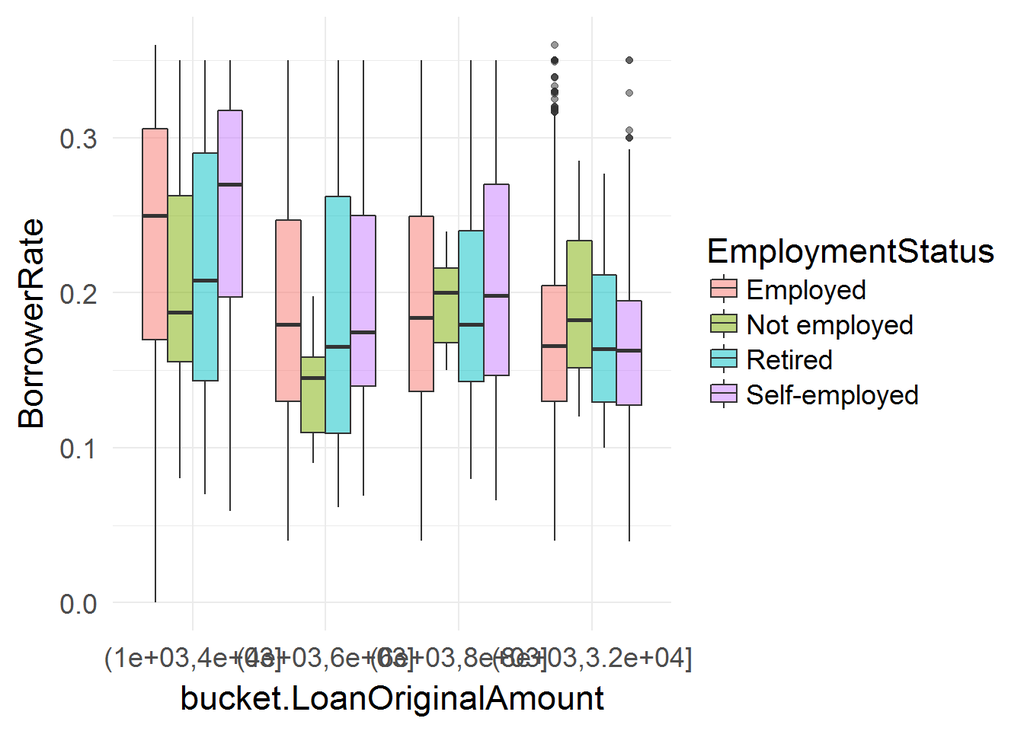

we can see as the loan amount increases, not employed customer tends to have higher borrower rate in compate to others, also it seems Retired customer seems to get lower rate in compare to other groups

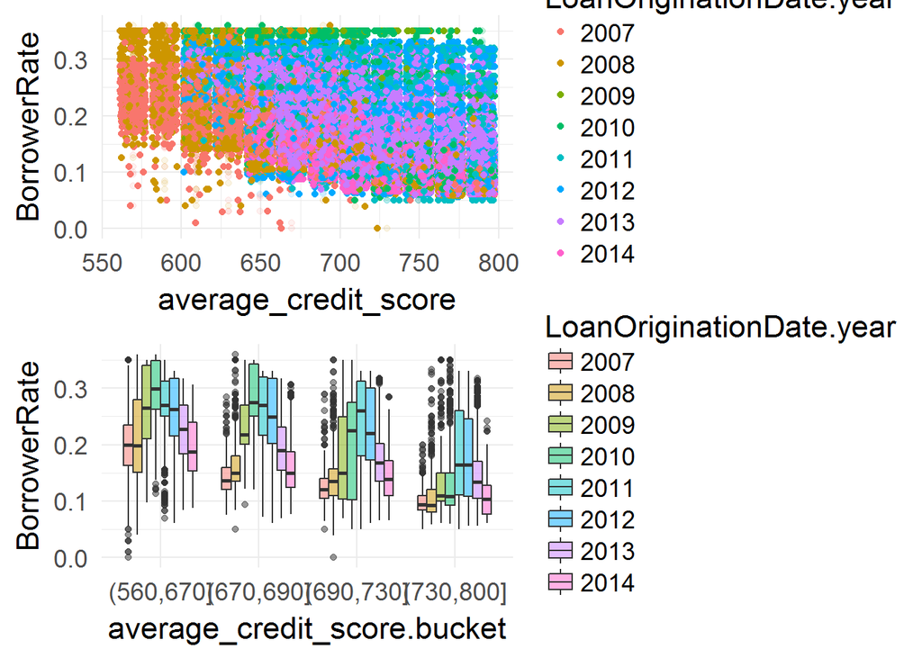

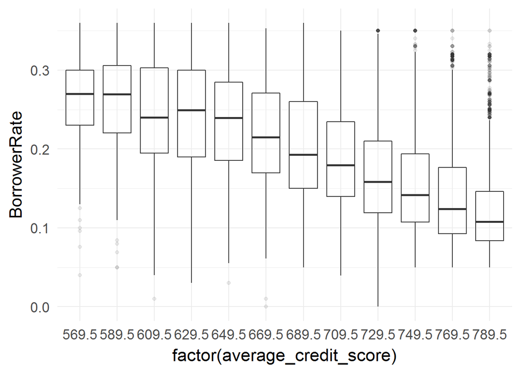

by looking at the boxes and medians we can see having higher credit score cause to get lower borrower rate

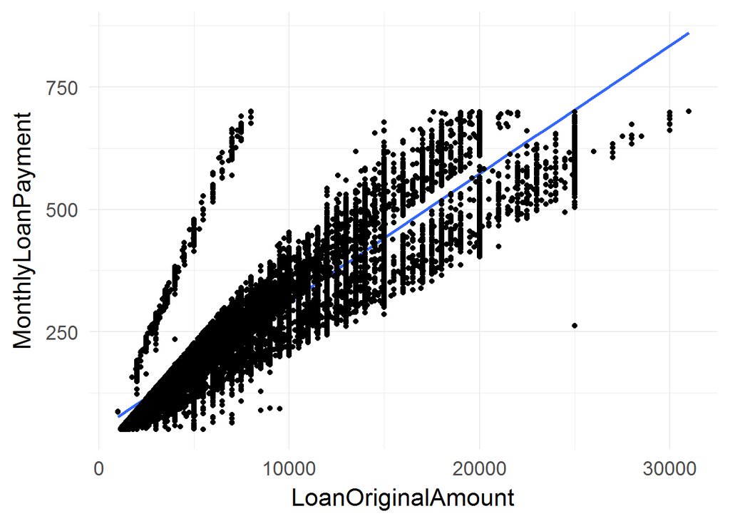

looking at the plot there seems to be intresting linear relation in upper portion of the data, we can see the upper line has a monthly loan payment > 250 and loan original amount less than 10000 so i am subseting the data

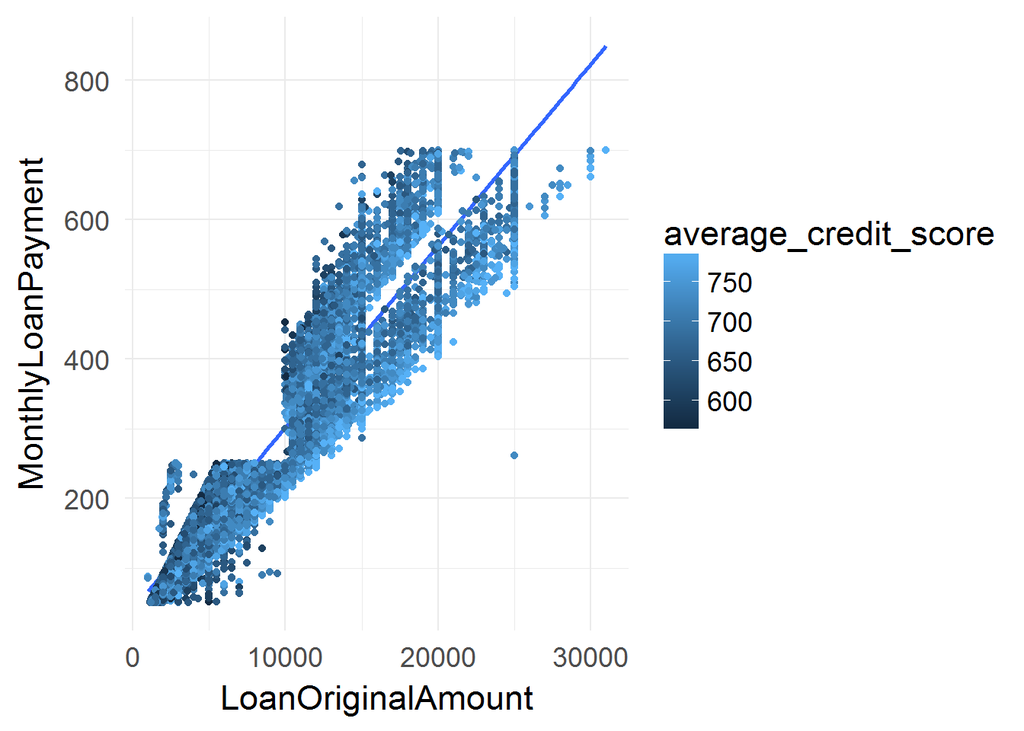

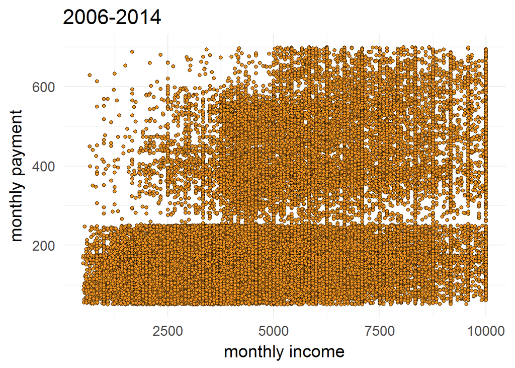

plot here does not show much as we have high density in the middle , i can see a quadratic curve in the data. however i am not using log as the range of monthtly income and monthly payment is not that different. i will use income range and look at the monthly payment based on the range

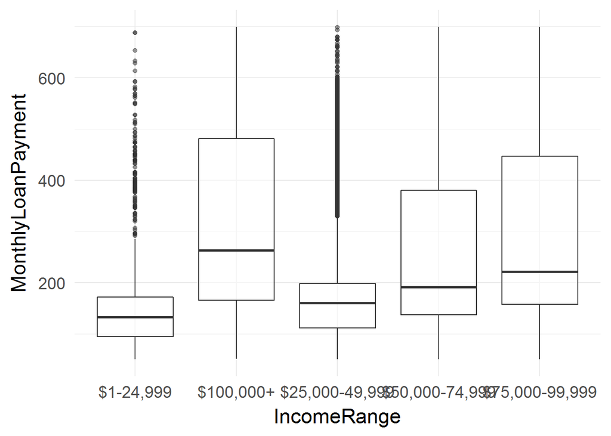

we can see as income range increases the monthly payment also increase, now i use loan year as a factor and re plot to see if we can find any important information

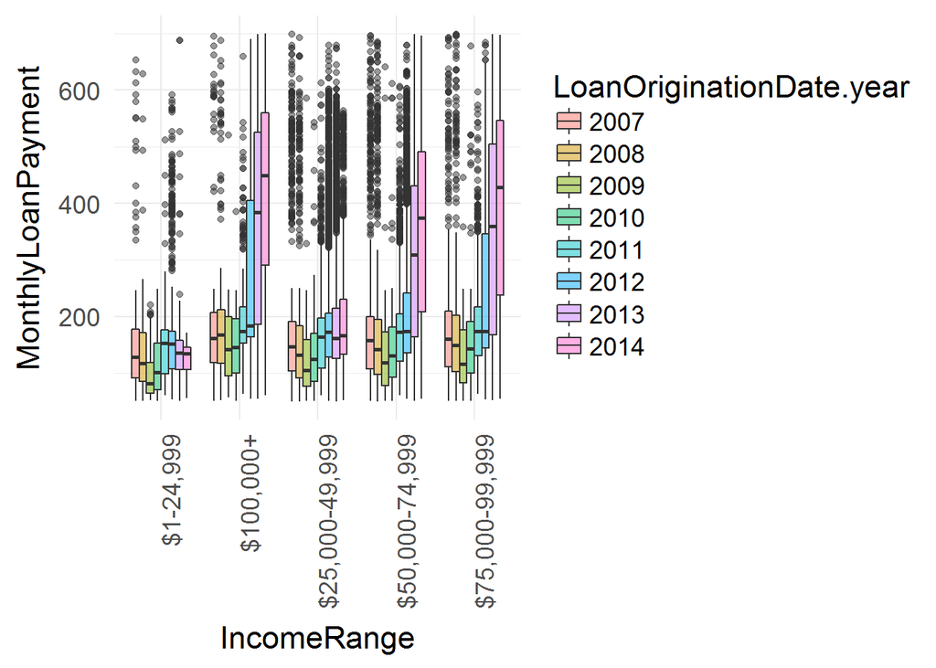

we can see within last few years(2011-2014) having higher income range will be ending in more monthly loan payments, and intresting fact for me was that in 2009 and 2010 we are having the lowest monthly payment

# developing a Linear model

```
##
## Calls:
## m1: lm(formula = MonthlyLoanPayment ~ StatedMonthlyIncome, data = data)
## m2: lm(formula = MonthlyLoanPayment ~ StatedMonthlyIncome + BorrowerRate +
##     LP_CustomerPayments + InquiriesLast6Months, data = data)
## m3: lm(formula = MonthlyLoanPayment ~ StatedMonthlyIncome + BorrowerRate +
##     LP_CustomerPayments + InquiriesLast6Months + LoanOriginationDate.month +
##     LoanOriginationDate.year + DebtToIncomeRatio + OpenCreditLines,
##     data = data)
## m4: lm(formula = MonthlyLoanPayment ~ StatedMonthlyIncome + BorrowerRate +
##     LP_CustomerPayments + InquiriesLast6Months + LoanOriginationDate.month +
##     LoanOriginationDate.year + DebtToIncomeRatio + OpenCreditLines +
##     LP_CustomerPrincipalPayments + LoanOriginalAmount + Term +
##     average_credit_score, data = data)
##
## ============================================================================================
##                                             m1            m2           m3           m4
## --------------------------------------------------------------------------------------------
##   (Intercept)                           101.748***    191.017***    -31.704***  144.676***
##                                          (1.450)       (2.263)       (3.329)     (2.495)
##   StatedMonthlyIncome                     0.027***      0.025***      0.019***   -0.000
##                                          (0.000)       (0.000)       (0.000)     (0.000)
##   BorrowerRate                                       -451.328***   -284.872***  180.012***
##                                                        (7.602)       (7.467)     (2.419)
##   LP_CustomerPayments                                   0.008***      0.029***    0.008***
##                                                        (0.000)       (0.000)     (0.000)
##   InquiriesLast6Months                                 -6.373***      1.801***    0.422***
##                                                        (0.286)       (0.264)     (0.066)
##   LoanOriginationDate.month: Aug/Apr                                 14.106***    0.893
##                                                                      (2.492)     (0.621)
##   LoanOriginationDate.month: Dec/Apr                                 56.854***    2.866***
##                                                                      (2.487)     (0.624)
##   LoanOriginationDate.month: Feb/Apr                                 -9.669***   -1.744**
##                                                                      (2.704)     (0.673)
##   LoanOriginationDate.month: Jan/Apr                                -19.348***   -1.933**
##                                                                      (2.693)     (0.671)
##   LoanOriginationDate.month: Jul/Apr                                  7.439**     0.238
##                                                                      (2.484)     (0.619)
##   LoanOriginationDate.month: Jun/Apr                                  5.556*      1.369*
##                                                                      (2.513)     (0.626)
```

[output cut: 33 more lines]

```
##                                                                                  (0.013)
##   average_credit_score                                                           -0.031***
##                                                                                  (0.003)
## --------------------------------------------------------------------------------------------
##   R-squared                                     0.1           0.2          0.5         1.0
##   adj. R-squared                                0.1           0.2          0.5         1.0
##   sigma                                       142.2         135.8        113.7        28.3
##   F                                          9887.9        4162.8       1990.0     58290.9
##   p                                             0.0           0.0          0.0         0.0
##   Log-likelihood                          -388104.1     -385287.0    -350124.7   -270980.7
##   Deviance                             1230530808.7  1123034597.3  735494535.7  45564069.0
##   AIC                                      776214.1      770586.1     700301.4    542021.4
##   BIC                                      776241.2      770640.2     700534.1    542289.9
##   N                                         60869         60863        56909       56909
## ============================================================================================
```

last few plots shows that we can use some of the variables inside the model and add other variables and check the results, we can see we have good R-squared and adjusted R-squared, however there is a chance of over fitting which i have not consider for this project. also to be sure of chosen variables are rubust i am using an automatic variable selection based on forward and backeward regression using AIC metric

```
## Start:  AIC=197768.4
## MonthlyLoanPayment ~ (BorrowerRate + LoanStatus + LP_CustomerPayments +
##     TotalInquiries + InquiriesLast6Months + LoanOriginationDate.month +
##     LoanOriginationDate.year + DebtToIncomeRatio + OpenCreditLines +
##     LP_CustomerPrincipalPayments + StatedMonthlyIncome + LoanOriginalAmount +
##     Term + EmploymentStatus + AmountDelinquent + bucket.InquiriesLast6Months +
##     BankcardUtilization + IncomeRange + average_credit_score +
##     bucket.LoanOriginalAmount + average_credit_score.bucket) -
##     LoanStatus
##
##                                Df Sum of Sq      RSS    AIC
## - EmploymentStatus              3      2615 19328445 197767
## - InquiriesLast6Months          1       155 19325985 197767
## - BankcardUtilization           1       272 19326102 197767
## - StatedMonthlyIncome           1       400 19326230 197767
## <none>                                      19325830 197768
## - OpenCreditLines               1      1824 19327654 197769
## - TotalInquiries                1      1989 19327819 197770
## - bucket.InquiriesLast6Months   2      5795 19331625 197774
## - AmountDelinquent              1      5915 19331745 197776
## - LoanOriginationDate.month    11     23203 19349034 197783
## - IncomeRange                   4     18615 19344446 197790
## - DebtToIncomeRatio             1     51189 19377019 197847
## - average_credit_score          1     94099 19419930 197915
## - LP_CustomerPrincipalPayments  1    143080 19468910 197993
## - average_credit_score.bucket   3    175898 19501728 198040
## - LP_CustomerPayments           1    225559 19551389 198122
## - LoanOriginationDate.year      7   1005856 20331686 199310
## - bucket.LoanOriginalAmount     3   3213329 22539159 202479
## - BorrowerRate                  1   3885813 23211643 203385
## - Term                          1  34103528 53429358 228951
## - LoanOriginalAmount            1  71403430 90729260 245189
##
## Step:  AIC=197766.5
## MonthlyLoanPayment ~ BorrowerRate + LP_CustomerPayments + TotalInquiries +
##     InquiriesLast6Months + LoanOriginationDate.month + LoanOriginationDate.year +
##     DebtToIncomeRatio + OpenCreditLines + LP_CustomerPrincipalPayments +
##     StatedMonthlyIncome + LoanOriginalAmount + Term + AmountDelinquent +
##     bucket.InquiriesLast6Months + BankcardUtilization + IncomeRange +
##     average_credit_score + bucket.LoanOriginalAmount + average_credit_score.bucket
```

[output cut: 100 more lines]

```
## + EmploymentStatus              3      2643 19326707 197764
## - bucket.InquiriesLast6Months   2      6419 19335768 197768
## - AmountDelinquent              1      5873 19335223 197769
## - LoanOriginationDate.month    11     23178 19352528 197777
## - IncomeRange                   4     18546 19347895 197783
## - DebtToIncomeRatio             1     54326 19383676 197846
## - average_credit_score          1     98728 19428077 197916
## - LP_CustomerPrincipalPayments  1    142969 19472318 197986
## - average_credit_score.bucket   3    176852 19506201 198035
## - LP_CustomerPayments           1    225438 19554787 198116
## - LoanOriginationDate.year      7   1011168 20340518 199312
## - bucket.LoanOriginalAmount     3   3214769 22544118 202474
## - BorrowerRate                  1   3911650 23241000 203411
## - Term                          1  34117345 53446694 228949
## - LoanOriginalAmount            1  71535609 90864958 245223
```

```
##
## Call:
## lm(formula = MonthlyLoanPayment ~ BorrowerRate + LP_CustomerPayments +
##     TotalInquiries + LoanOriginationDate.month + LoanOriginationDate.year +
##     DebtToIncomeRatio + OpenCreditLines + LP_CustomerPrincipalPayments +
##     LoanOriginalAmount + Term + AmountDelinquent + bucket.InquiriesLast6Months +
##     IncomeRange + average_credit_score + bucket.LoanOriginalAmount +
##     average_credit_score.bucket, data = data)
##
## Coefficients:
##                              (Intercept)
##                                5.897e+01
##                             BorrowerRate
##                                2.362e+02
##                      LP_CustomerPayments
##                                4.454e-03
##                           TotalInquiries
##                                5.153e-02
##             LoanOriginationDate.monthAug
##                               -1.295e+00
##             LoanOriginationDate.monthDec
##                               -2.747e+00
##             LoanOriginationDate.monthFeb
##                               -2.907e+00
##             LoanOriginationDate.monthJan
##                               -1.828e+00
##             LoanOriginationDate.monthJul
##                               -1.060e+00
##             LoanOriginationDate.monthJun
##                               -6.625e-02
##             LoanOriginationDate.monthMar
##                               -1.478e+00
##             LoanOriginationDate.monthMay
##                               -7.905e-01
##             LoanOriginationDate.monthNov
##                               -2.888e+00
##             LoanOriginationDate.monthOct
##                               -1.461e+00
##             LoanOriginationDate.monthSep
##                               -1.949e+00
```

[output cut: 37 more lines]

```
##                                2.030e+00
##                     average_credit_score
##                                1.039e-01
##   bucket.LoanOriginalAmount(4e+03,6e+03]
##                                2.345e+01
##   bucket.LoanOriginalAmount(6e+03,8e+03]
##                                3.880e+01
## bucket.LoanOriginalAmount(8e+03,3.2e+04]
##                                6.404e+01
##     average_credit_score.bucket(670,690]
##                               -2.889e+00
##     average_credit_score.bucket(690,730]
##                               -6.555e+00
##     average_credit_score.bucket(730,800]
##                               -1.549e+01
```

```
##
## Call:
## lm(formula = MonthlyLoanPayment ~ . - LoanStatus, data = data)
##
## Residuals:
##     Min      1Q  Median      3Q     Max
## -488.63  -12.20   -2.53    9.26  139.34
##
## Coefficients:
##                                            Estimate Std. Error  t value
## (Intercept)                               6.019e+01  5.611e+00   10.727
## BorrowerRate                              2.364e+02  3.013e+00   78.463
## LP_CustomerPayments                       4.456e-03  2.357e-04   18.904
## TotalInquiries                            5.980e-02  3.369e-02    1.775
## InquiriesLast6Months                     -5.529e-02  1.115e-01   -0.496
## LoanOriginationDate.monthAug             -1.282e+00  7.405e-01   -1.732
## LoanOriginationDate.monthDec             -2.738e+00  7.537e-01   -3.633
## LoanOriginationDate.monthFeb             -2.915e+00  8.038e-01   -3.627
## LoanOriginationDate.monthJan             -1.840e+00  8.028e-01   -2.292
## LoanOriginationDate.monthJul             -1.045e+00  7.355e-01   -1.420
## LoanOriginationDate.monthJun             -5.658e-02  7.424e-01   -0.076
## LoanOriginationDate.monthMar             -1.492e+00  7.622e-01   -1.957
## LoanOriginationDate.monthMay             -7.962e-01  7.494e-01   -1.062
## LoanOriginationDate.monthNov             -2.881e+00  7.632e-01   -3.775
## LoanOriginationDate.monthOct             -1.448e+00  7.265e-01   -1.994
## LoanOriginationDate.monthSep             -1.940e+00  7.441e-01   -2.607
## LoanOriginationDate.year2008             -4.549e+00  6.173e-01   -7.369
## LoanOriginationDate.year2009             -8.882e+00  1.198e+00   -7.416
## LoanOriginationDate.year2010             -9.637e+00  8.768e-01  -10.992
## LoanOriginationDate.year2011             -4.142e+00  7.566e-01   -5.475
## LoanOriginationDate.year2012              8.069e+00  6.939e-01   11.628
## LoanOriginationDate.year2013              1.246e+01  6.964e-01   17.887
## LoanOriginationDate.year2014              1.221e+01  9.921e-01   12.304
## DebtToIncomeRatio                         9.655e+00  1.072e+00    9.006
## OpenCreditLines                          -5.920e-02  3.482e-02   -1.700
## LP_CustomerPrincipalPayments             -4.272e-03  2.837e-04  -15.056
## StatedMonthlyIncome                      -1.985e-04  2.493e-04   -0.796
## LoanOriginalAmount                        2.630e-02  7.818e-05  336.346
## Term                                     -4.072e+00  1.752e-02 -232.448
## EmploymentStatusNot employed             -4.654e+00  8.908e+00   -0.522
```

[output cut: 57 more lines]

```
## IncomeRange$75,000-99,999                0.038747 *
## average_credit_score                      < 2e-16 ***
## bucket.LoanOriginalAmount(4e+03,6e+03]    < 2e-16 ***
## bucket.LoanOriginalAmount(6e+03,8e+03]    < 2e-16 ***
## bucket.LoanOriginalAmount(8e+03,3.2e+04]  < 2e-16 ***
## average_credit_score.bucket(670,690]     7.92e-08 ***
## average_credit_score.bucket(690,730]      < 2e-16 ***
## average_credit_score.bucket(730,800]      < 2e-16 ***
## ---
## Signif. codes:  0 '***' 0.001 '**' 0.01 '*' 0.05 '.' 0.1 ' ' 1
##
## Residual standard error: 25.12 on 30619 degrees of freedom
##   (30203 observations deleted due to missingness)
## Multiple R-squared:  0.9713, Adjusted R-squared:  0.9713
## F-statistic: 2.257e+04 on 46 and 30619 DF,  p-value: < 2.2e-16
```

# **Final Plots and Summary**

### Plot One and Two

we have seen Loan Origin amount has siginificant correlation with the borrower rate, i have used employment status also to look deeper into the data and see the patterns, which we have seen for employment status and different loan amount we have differnet borrower rates.

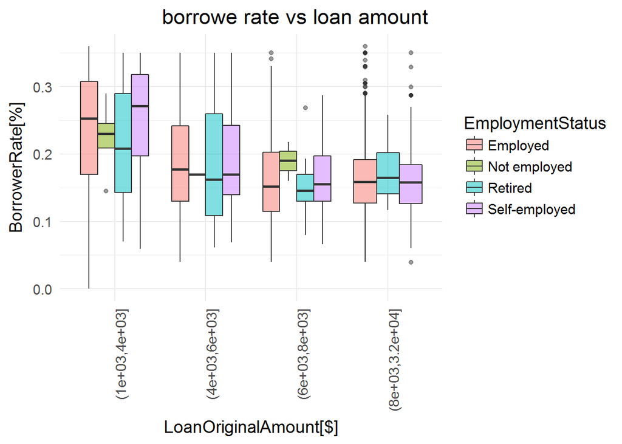

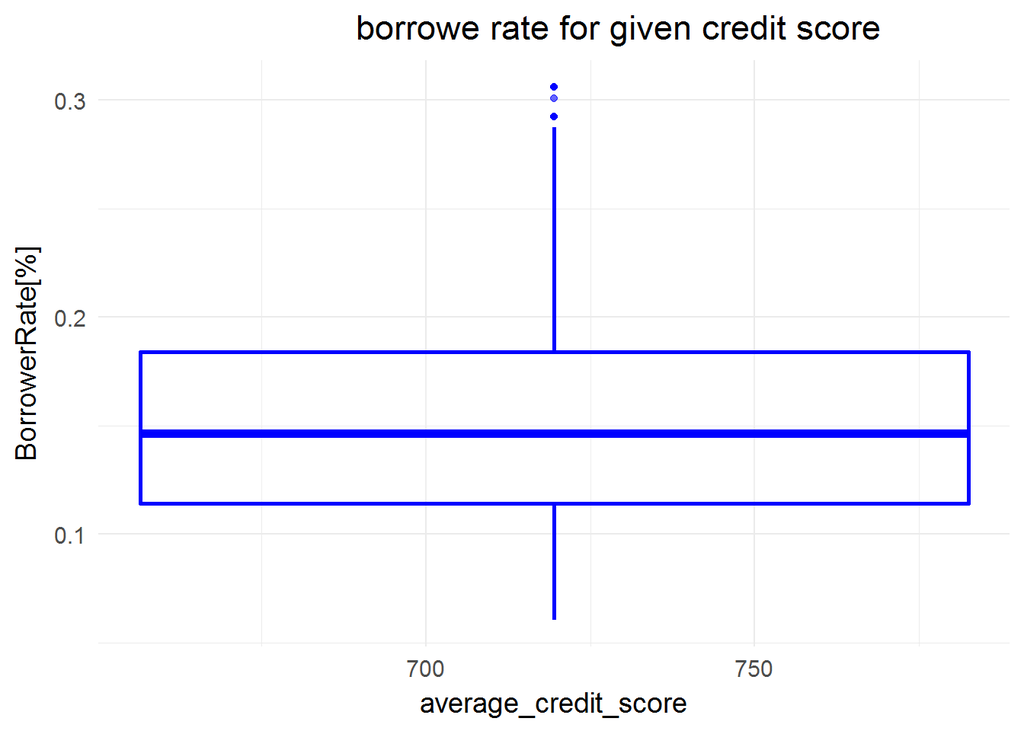

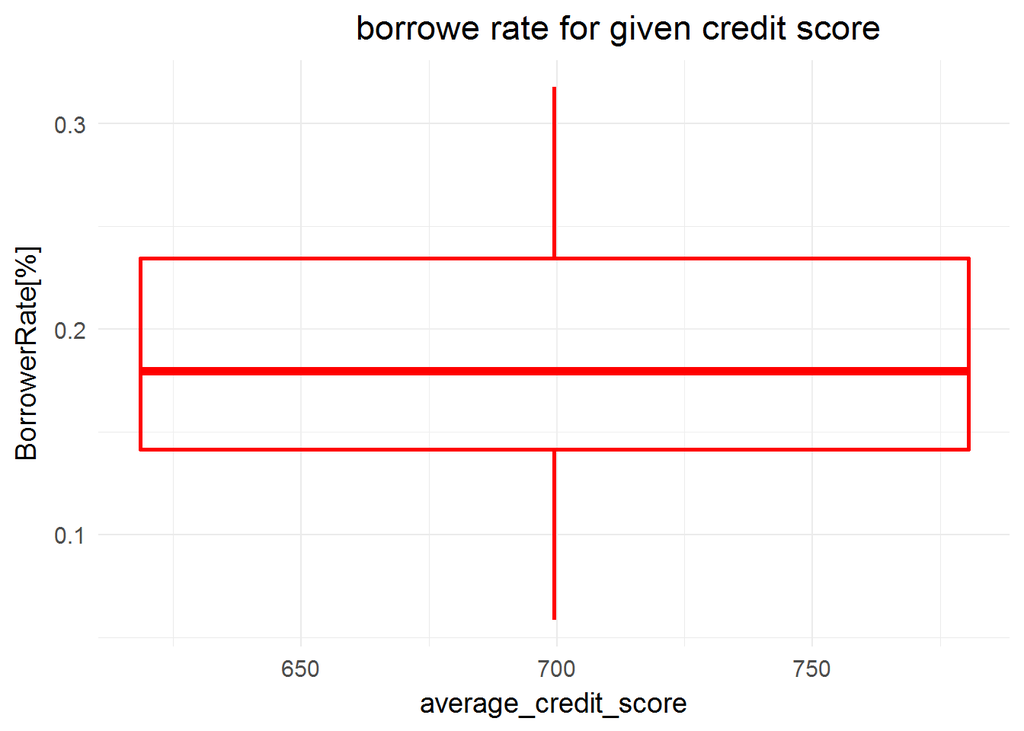

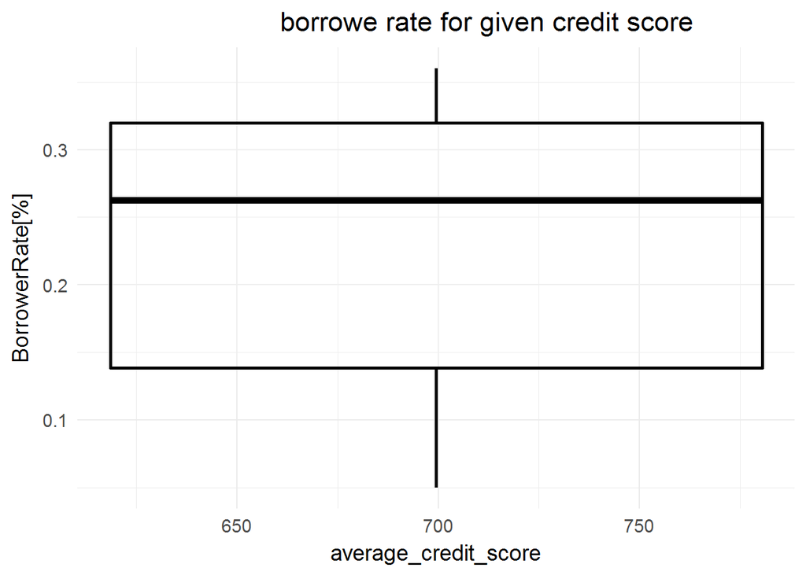

i have found withing last few years(2011-2014) being in higher income range class will cause to pay more payment monthly.

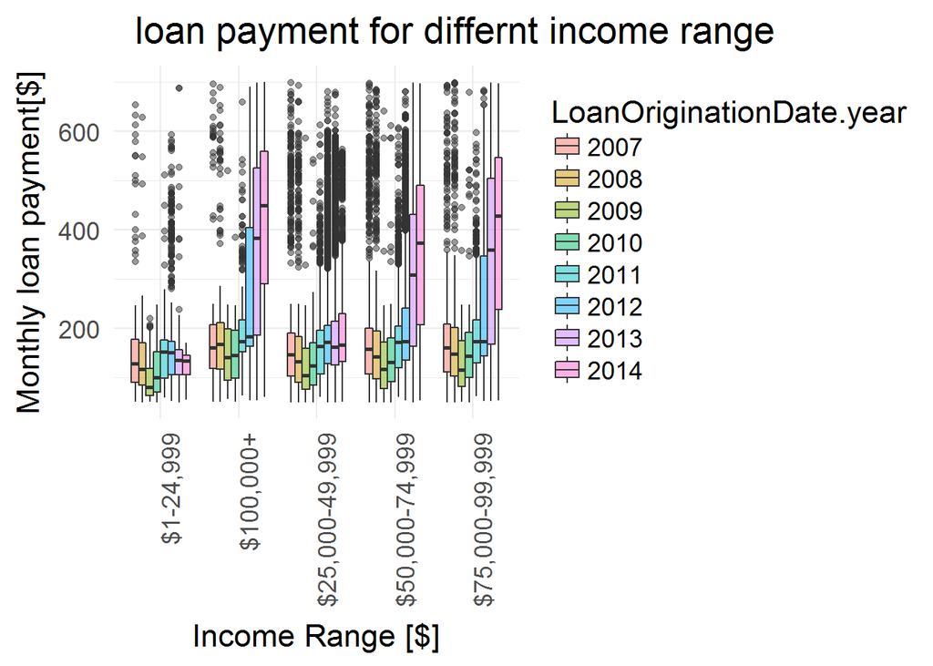

# **Reflections**

## Issues

Are the following conclusions certain? No. There seems we need more data wrangling and cleaning on this data set.Also we need to have more records with usable values. Regarding this project I struggled with finding the relationship between the variables initially. It was hard for me to decide which variables are dependent, which are independent and which I should keep in my analysis.Through exploring, I found a borrower rate as my dependent variable and I designed my project around that.

## Conclusion

It seems that credit score has more impact on borrow rate within last few years, after 2010 we can see that having higher credit score gives us lower rates.

Intrestingly I found that having higher loan amount seems to decrease the borrow rate, however we need more data to approve this hypothesis.